# Varroa sup1

Kevin Healy

2024-03-15

## Varroa Supplementary Analysis

This is a repeat of the main analysis but with an offset of 1% of the given response values for a given treatment on a given response target for a given study. This will allow for the inclusion of any ratios with zero’s in either the denominator or numerator.

This document outlines the code used for the analysis in O Connell et al 2024 regarding the effects of various treatments on Varroa based on a literature search (see main manuscript for details). The analysis measures the effect of various treatments using the log ratio between the treatment and its associated control. This approach allows us to compared values from various sources and treatments from a wide general perspective.

# Load up Packages

We will use the MCMCglmm package which allows us to run mixed effects models in a Bayesian framework.

```r
library(MCMCglmm)
library(hdrcde)
```

# Data

The raw data set Varroa_treatment_database_2024.12.18.csv can be found in the supplementary of the manuscript. Once loaded we will also create a new variable which further splits the category Chemical into “Synthetic” and “Agriculturally_Organic”.

```r
varroa_data <- read.csv("Varroa_treatment_database_2024.12.18.csv",
                        sep = ",",
                        header = T)


#we will add a breakdown of synthetic versus non synthetic
chem_split <- as.vector(varroa_data$categoryTreatment)

#We will loop around and replace the the term Chemical with its entry in the
#SubCategory1Treatment variable
for(i in 1:length(chem_split)){

  if(chem_split[i] == "Chemical")
    {chem_split[i] <- varroa_data$SubCategory1Treatment[i]}
}

#Set it so Synthetic chemicals are the baseline.
chem_split <- factor(chem_split, levels = c("Synthetic",
                                            "Agriculturally_Organic",
                                            "Biological",
                                            "Physical",
                                            "Mixed"))

#Add this new chem_split variable to the data set.
varroa_data <-  data.frame(varroa_data,
                                    chem_split)
```

## log ratio calculations

To calculate the log ratio vales we use a loop so that for every study we calculate the pairwise log ratio between the studies control and each of the treatment measures as log(treatment/control).

There are four different broad measurement types in the analysis. (1) HoneyBeeIncrease: Those that measure aspects of honey bees where an increase in the measure is a measure of the positive effects of the treatment. For example, if the number of bees increases in response to some treatment.

2. HoneyBeeReduction Those that measure aspects of honey bees where a increase in the measure is a measure of the negative effects of the treatment. For example, if the mortality rate of bees increases in response to some treatment.
3. VarroaReduction: Those that measure aspects of Varroa where an increase in the measure is a measure of the positive effects of the treatment. For example, if the Varroa mortality rate increases in response to some treatment.
4. VarroaIncrease: Those that measure aspects of Varroa where an increase in the measure is a measure of the negative effects of the treatment. For example, if the Varroa population size increases in response to some treatment.

In order to include all 4 of these groups together in the main analysis we reversed the sign for the log ratio of HoneyBeeReduction and VarroaIncrease values so that positive values indicate positive outcomes for bee control.

We do not include any infinite ratios caused by either log(1/0) or log(0/1). We change log(0/0) values to zero as while it gives an NA a zero value of no change is comparable to values such as log(1/1).

First we will create a loop for each of the Response Variable Category types (HoneyBeeIncrease, HoneyBeeReduction, VarroaIncrease, VarroaReduction)

# HoneyBeeIncrease

Loop matching up all the treatments and controls for measures where an increase is a positive outcome for bees. This loop only compares treatment values within studies and for the same response target (for example, within studies there may be several response targets such as adults, juveniles etc). 3 measures are dropped as the control and treatments have different signs leading to log(-t/c) which cannot be computed.

```r
#subset to just responses with HoneyBeeIncrease
HoneyBeeIncrease_data <- varroa_data[varroa_data$ResponseVariableCategory ==
                                       "HoneyBeeIncrease",]

#create a column that has unique treatment and response numbers
HoneyBeeIncrease_data$tre_resp <-  paste(HoneyBeeIncrease_data$Treatment_Group,
                                         "_",
                                         HoneyBeeIncrease_data$ResponseNo.,
                                         sep = "")

#empty list to put the final paired rows into
HoneyBeeIncrease_tret_group_temp <- list()

#Data for every study
for (i in 1:length(unique(HoneyBeeIncrease_data$StudyID))){

  hbi_stud <- HoneyBeeIncrease_data[HoneyBeeIncrease_data$StudyID ==
                                      unique(HoneyBeeIncrease_data$StudyID)[i],]
  #Data for every response target (juvinal. adult etc)
  for(z in 1:length(unique(hbi_stud$ResponseVariableTarget))){

    hbi_stud_res <- hbi_stud[hbi_stud$ResponseVariableTarget ==
                               unique(hbi_stud$ResponseVariableTarget)[z],]

     for(w in 1:length(unique(hbi_stud_res$tre_resp))){

       hbi_tret <- hbi_stud_res[hbi_stud_res$tre_resp ==
                                  unique(hbi_stud_res$tre_resp)[w],]

       #This given the median value across the responses for this study
       median_hbi_tret_res <- median(hbi_tret$specificResponseMean)

#HoneyBeeIncrease_tret_group_temp <- vector()

        for(t in 1:length(hbi_tret[hbi_tret$Status != "control",1])){

#we default to the first control for now.
hbi_control <- hbi_tret[hbi_tret$Status == "control", ][1,]

#rename the colunm names to _control
colnames(hbi_control) <- paste(names(hbi_control),"_control",sep = "")

#we default to the first control for now.
HoneyBeeIncrease_tret_group_temp[[length(HoneyBeeIncrease_tret_group_temp)+1]]<-
  cbind(hbi_tret[hbi_tret$Status != "control",][t,],
                   hbi_control, median_hbi_tret_res)

        }
    }
  }
  }

#Now we just
HoneyBeeIncrease_paired <- do.call(rbind.data.frame,
                                   HoneyBeeIncrease_tret_group_temp)

#We can add a row of the log ratio of the response mean value
#(specificResponseMean) divided by the control (specificResponseMean_control)

HoneyBeeIncrease_paired$logratio <-
  log(c(HoneyBeeIncrease_paired$specificResponseMean +
          HoneyBeeIncrease_paired$median_hbi_tret_res*0.01)/
        c(HoneyBeeIncrease_paired$specificResponseMean_control +
            HoneyBeeIncrease_paired$median_hbi_tret_res*0.01))
HoneyBeeIncrease_paired_fin <- HoneyBeeIncrease_paired[!(is.nan(HoneyBeeIncrease_paired$logratio)),]

#Lets just set Chemical as the baseline
HoneyBeeIncrease_paired_fin$categoryTreatment <-
  factor(HoneyBeeIncrease_paired_fin$categoryTreatment,
                                                        levels = c("Chemical",
                                                                   "Physical",
                                                                   "Biological",
                                                                   "Mixed")
                                                        )

#create a variable that gives a unique identify for nested country continent
HoneyBeeIncrease_paired_fin$Cont_Country <-
  paste0(HoneyBeeIncrease_paired_fin$Continent,
          HoneyBeeIncrease_paired_fin$Country)
```

## HoneyBeeReduction

Loop matching up all the treatments and controls for measures where a decrease is a positive outcome for bees. This loop only compares treatment values within studies and for the same response target (for example, within studies there may be several response targets such as adults, juveniles etc). After zero adjusting there are 3 NaN values which are caused by the control and treatment having different signs to their values.(59 values where originally dropped)

```r
#subset to just responses with HoneyBeeIncrease
HoneyBeeReduction_data <- varroa_data[varroa_data$ResponseVariableCategory ==
                                       "HoneyBeeReduction",]

#create a column that has unique treatment and response numbers
HoneyBeeReduction_data$tre_resp <-  paste(HoneyBeeReduction_data$Treatment_Group,
                                         "_",
                                         HoneyBeeReduction_data$ResponseNo.,
                                         sep = "")

#empty list to put the final paired rows into
HoneyBeeReduction_tret_group_temp <- list()

#Data for every study
for (i in 1:length(unique(HoneyBeeReduction_data$StudyID))){

  hbr_stud <- HoneyBeeReduction_data[HoneyBeeReduction_data$StudyID ==
                                      unique(HoneyBeeReduction_data$StudyID)[i],]
  #Data for every response target (juvinal. adult etc)
  for(z in 1:length(unique(hbr_stud$ResponseVariableTarget))){

    hbr_stud_res <- hbr_stud[hbr_stud$ResponseVariableTarget ==
                               unique(hbr_stud$ResponseVariableTarget)[z],]

     for(w in 1:length(unique(hbr_stud_res$tre_resp))){

hbr_tret <- hbr_stud_res[hbr_stud_res$tre_resp==unique(hbr_stud_res$tre_resp)[w],]

       #This given the median value across the responses
            median_hbr_tret_res <- median(hbr_tret$specificResponseMean)

        for(t in 1:length(hbr_tret[hbr_tret$Status != "control",1])){


#we default to the first control for now.
hbr_control <- hbr_tret[hbr_tret$Status == "control", ][1,]

#rename the colunm names to _control
colnames(hbr_control) <- paste(names(hbr_control),"_control",sep = "")

#we default to the first control for now.
HoneyBeeReduction_tret_group_temp[[length(HoneyBeeReduction_tret_group_temp)+1]]<-
  cbind(hbr_tret[hbr_tret$Status != "control",][t,],
                   hbr_control, median_hbr_tret_res)

        }
    }
  }
  }

#Now we just
HoneyBeeReduction_paired <- do.call(rbind.data.frame,
                                    HoneyBeeReduction_tret_group_temp)

#We can add a row of the log ratio of the response mean value
#(specificResponseMean) divided by the control (specificResponseMean_control)

HoneyBeeReduction_paired$logratio <-
  log(c(HoneyBeeReduction_paired$specificResponseMean +
          HoneyBeeReduction_paired$median_hbr_tret_res*0.01)/
        c(HoneyBeeReduction_paired$specificResponseMean_control +
            HoneyBeeReduction_paired$median_hbr_tret_res*0.01))
##From looking at the data values for 154,155,156 should have 0 values
#The loop does not work as the zero adjustment is also zero.
HoneyBeeReduction_paired$logratio[154:156] <- c(0)

#This give infinity due to the zero adjustment is also being zero
#So here we will adjust by 1% of the response varible
HoneyBeeReduction_paired$logratio[157] <- log(c(20+ 20*0.01)/c(20*0.01))


HoneyBeeReduction_paired_fin <- HoneyBeeReduction_paired[!(is.nan(HoneyBeeReduction_paired$logratio)),]

#Lets just set Chemical as the baseline
HoneyBeeReduction_paired_fin$categoryTreatment <-
  factor(HoneyBeeReduction_paired_fin$categoryTreatment,
                                                        levels = c("Chemical",
                                                                   "Physical",
                                                                   "Biological",
                                                                   "Mixed")
                                                        )

#create a variable that gives a unique identify for nested country continent
HoneyBeeReduction_paired_fin$Cont_Country <-
  paste0(HoneyBeeReduction_paired_fin$Continent,
         HoneyBeeReduction_paired_fin$Country)


#We can also create a version of the data set
#with the log ratio value flipped so that it can be read as a positive value

HoneyBeeReduction_paired_red_fin <- HoneyBeeReduction_paired_fin

HoneyBeeReduction_paired_red_fin$logratio <-
  -HoneyBeeReduction_paired_red_fin$logratio
```

## VarroaIncrease

Loop matching up all the treatments and controls for measures where a decrease is a positive outcome for bees. This loop only compares treatment values within studies and for the same response target (for example, within studies there may be several response targets such as adults, juveniles etc). No values where removed (originally 29 infinite values were removed)

```r
#subset to just responses with VarroaIncrease
VarroaIncrease_data <- varroa_data[varroa_data$ResponseVariableCategory ==
                                       "VarroaIncrease",]

#create a column that has unique treatment and response numbers
VarroaIncrease_data$tre_resp <-  paste(VarroaIncrease_data$Treatment_Group,
                                         "_",
                                         VarroaIncrease_data$ResponseNo.,
                                         sep = "")

#empty list to put the final paired rows into
VarroaIncrease_tret_group_temp <- list()

#Data for every study
for (i in 1:length(unique(VarroaIncrease_data$StudyID))){

  vi_stud <- VarroaIncrease_data[VarroaIncrease_data$StudyID ==
                                      unique(VarroaIncrease_data$StudyID)[i],]
  #Data for every response target (juvinal. adult etc)
  for(z in 1:length(unique(vi_stud$ResponseVariableTarget))){

    vi_stud_res <- vi_stud[vi_stud$ResponseVariableTarget ==
                               unique(vi_stud$ResponseVariableTarget)[z],]

     for(w in 1:length(unique(vi_stud_res$tre_resp))){

vi_tret <- vi_stud_res[vi_stud_res$tre_resp == unique(vi_stud_res$tre_resp)[w],]


        median_vi_tret_res <- median(vi_tret$specificResponseMean)


        for(t in 1:length(vi_tret[vi_tret$Status != "control",1])){

#we default to the first control for now.
vi_control <- vi_tret[vi_tret$Status == "control", ][1,]

#rename the colunm names to _control
colnames(vi_control) <- paste(names(vi_control),"_control",sep = "")

#we default to the first control for now.
VarroaIncrease_tret_group_temp[[length(VarroaIncrease_tret_group_temp) + 1]]  <-
  cbind(vi_tret[vi_tret$Status != "control",][t,],
                   vi_control, median_vi_tret_res)

        }
    }
  }
  }

#Now we just
VarroaIncrease_paired <- do.call(rbind.data.frame, VarroaIncrease_tret_group_temp)

#We can add a row of the log ratio of the response mean value
#(specificResponseMean) divided by the control (specificResponseMean_control)

VarroaIncrease_paired$logratio <-
  log(c(VarroaIncrease_paired$specificResponseMean +
          median_vi_tret_res*0.01)/
        c(VarroaIncrease_paired$specificResponseMean_control +
            median_vi_tret_res*0.01))
VarroaIncrease_paired_fin <- VarroaIncrease_paired


#Lets just set Chemical as the baseline
VarroaIncrease_paired_fin$categoryTreatment <-
  factor(VarroaIncrease_paired_fin$categoryTreatment,
                                                        levels = c("Chemical",
                                                                   "Physical",
                                                                   "Biological",
                                                                   "Mixed")
                                                        )

#create a variable that gives a unique identify for nested country continent
VarroaIncrease_paired_fin$Cont_Country <-
  paste0(VarroaIncrease_paired_fin$Continent,
         VarroaIncrease_paired_fin$Country)



#We can also create a version of the dataset
#with the log ratio value flipped so that it can be read as a positive value

VarroaIncrease_paired_red_fin <- VarroaIncrease_paired_fin
VarroaIncrease_paired_red_fin$logratio <- -VarroaIncrease_paired_red_fin$logratio
```

## VarroaReduction

Loop matching up all the treatments and controls for measures where an increase is a positive outcome for bees. This loop only compares treatment values within studies and for the same response target (for example, within studies there may be several response targets such as adults, juveniles etc). 1 NaN value was removed due to change in sign between control and main value. Originally 300 infinite values were removed.

```r
#subset to just responses with VarroaReduction
VarroaReduction_data <- varroa_data[varroa_data$ResponseVariableCategory ==
                                       "VarroaReduction",]

#create a column that has unique treatment and response numbers
VarroaReduction_data$tre_resp <-  paste(VarroaReduction_data$Treatment_Group,
                                         "_",
                                         VarroaReduction_data$ResponseNo.,
                                         sep = "")

#empty list to put the final paired rows into
VarroaReduction_tret_group_temp <- list()

#Data for every study
for (i in 1:length(unique(VarroaReduction_data$StudyID))){

  vr_stud <- VarroaReduction_data[VarroaReduction_data$StudyID ==
                                      unique(VarroaReduction_data$StudyID)[i],]
  #Data for every response target (juvinal. adult etc)
  for(z in 1:length(unique(vr_stud$ResponseVariableTarget))){

    vr_stud_res <- vr_stud[vr_stud$ResponseVariableTarget ==
                               unique(vr_stud$ResponseVariableTarget)[z],]

     for(w in 1:length(unique(vr_stud_res$tre_resp))){

vr_tret <- vr_stud_res[vr_stud_res$tre_resp == unique(vr_stud_res$tre_resp)[w],]

            median_vr_tret_res <- median(vr_tret$specificResponseMean)

#HoneyBeeIncrease_tret_group_temp <- vector()

        for(t in 1:length(vr_tret[vr_tret$Status != "control",1])){

#we default to the first control for now.
vr_control <- vr_tret[vr_tret$Status == "control", ][1,]

#rename the colunm names to _control
colnames(vr_control) <- paste(names(vr_control),"_control",sep = "")

#we default to the first control for now.
VarroaReduction_tret_group_temp[[length(VarroaReduction_tret_group_temp) + 1]]<-
  cbind(vr_tret[vr_tret$Status != "control",][t,],
                   vr_control, median_vr_tret_res)

        }
    }
  }
  }

#Now we just
VarroaReduction_paired <- do.call(rbind.data.frame,
                                  VarroaReduction_tret_group_temp)

#We can add a row of the log ratio of the response mean value
#(specificResponseMean) divided by the control (specificResponseMean_control)

VarroaReduction_paired$logratio <-
  log(c(VarroaReduction_paired$specificResponseMean +
          VarroaReduction_paired$median_vr_tret_res*0.01)/
        c(VarroaReduction_paired$specificResponseMean_control +
          VarroaReduction_paired$median_vr_tret_res*0.01))
```

```r
#From looking at the data the values for 731,732,733,735,736,737,738
#should be zero as all values are zero
VarroaReduction_paired$logratio[c(731,732,733,735,736,737,738)] <- c(0)

VarroaReduction_paired$logratio[727] <- log(c(VarroaReduction_paired$specificResponseMean[727] +
                                          VarroaReduction_paired$specificResponseMean[727]*0.01)/
                                       c(VarroaReduction_paired$specificResponseMean[727]*0.01))

VarroaReduction_paired$logratio[728] <- log(c(VarroaReduction_paired$specificResponseMean[728] +
                                          VarroaReduction_paired$specificResponseMean[728]*0.01)/
                                       c(VarroaReduction_paired$specificResponseMean[728]*0.01))

VarroaReduction_paired$logratio[729] <- log(c(VarroaReduction_paired$specificResponseMean[729] +
                                          VarroaReduction_paired$specificResponseMean[729]*0.01)/
                                       c(VarroaReduction_paired$specificResponseMean[729]*0.01))

VarroaReduction_paired$logratio[730] <- log(c(VarroaReduction_paired$specificResponseMean[730] +
                                          VarroaReduction_paired$specificResponseMean[730]*0.01)/
                                       c(VarroaReduction_paired$specificResponseMean[730]*0.01))

VarroaReduction_paired$logratio[734] <- log(c(VarroaReduction_paired$specificResponseMean[734] +
                                          VarroaReduction_paired$specificResponseMean[734]*0.01)/
                                       c(VarroaReduction_paired$specificResponseMean[734]*0.01))


VarroaReduction_paired_fin <-
  VarroaReduction_paired[!(is.nan(VarroaReduction_paired$logratio)),]

#lets remove any pairs that are infinite.
VarroaReduction_paired_fin <-
  VarroaReduction_paired[!(is.infinite(VarroaReduction_paired$logratio)),]


#Lets just set Chemical as the baseline
VarroaReduction_paired_fin$categoryTreatment <-
  factor(VarroaReduction_paired_fin$categoryTreatment,
                                                        levels = c("Chemical",
                                                                   "Physical",
                                                                   "Biological",
                                                                   "Mixed"
                                                                   )
                                                        )

#create a variable that gives a unique identify for nested country continent
VarroaReduction_paired_fin$Cont_Country <-
  paste0(VarroaReduction_paired_fin$Continent,
         VarroaReduction_paired_fin$Country)
```

We can join all the studies together with the sign reversed so that a positive difference indicates postie outcomes for control

We can combine the bee breeds into categories of C lineage (lugistica, carnica, lugistica/carnica hybrid, siciliana), A lineage (intermissa) O lineage (caucasia, anatolica, meda, syriaca), Africanised and Buckfast bees.

```r
#This just puts all the datasets together.

#We need to rename the median response column to match

names(HoneyBeeIncrease_paired_fin)[names(HoneyBeeIncrease_paired_fin) == "median_hbi_tret_res"] <- "median_res"
names(HoneyBeeReduction_paired_red_fin)[names(HoneyBeeReduction_paired_red_fin) == "median_hbr_tret_res"] <- "median_res"
names(VarroaIncrease_paired_red_fin)[names(VarroaIncrease_paired_red_fin) == "median_vi_tret_res"] <- "median_res"
names(VarroaReduction_paired_fin)[names(VarroaReduction_paired_fin) == "median_vr_tret_res"] <- "median_res"


#Notice HoneyBeeReduction_paired_red_fin and VarroaIncrease_paired_red_fin
#have their signs reversed
Full_comb_data <- rbind(HoneyBeeIncrease_paired_fin,
                             HoneyBeeReduction_paired_red_fin,
                             VarroaIncrease_paired_red_fin,
                             VarroaReduction_paired_fin)


################ Create bee breed catagories ###############
##############################################

#fix typo
Full_comb_data[Full_comb_data$Genetic_group_bees == "Apis_mellifer_carnica",
                  "Genetic_group_bees"] <- "Apis_mellifera_carnica"

Full_comb_data$Lineage <- Full_comb_data$Genetic_group_bees

#Set out C lineage
Full_comb_data[Full_comb_data$Lineage %in% c("Apis_mellifera_carnica",
"Apis_mellifera_ligustica_Apis_mellifera_carnica_natural_hybrids",
"Apis_mellifera_carnica_Apis_mellifera_ligustica_mixture",
"Apis_mellifera_siciliana",
"Apis_mellifera_ligustica"),
                              "Lineage"] <- "C_lineage"

#Set out A lineage
Full_comb_data[Full_comb_data$Lineage %in% c("Apis_mellifera_intermissa"),
                              "Lineage"] <- "A_lineage"

#Set out O lineage
Full_comb_data[Full_comb_data$Lineage %in% c("Apis_mellifera_anatolica",
                                                 "Apis_mellifera_meda",
                                             "Apis_mellifera_caucasica",
                                             "Apis_mellifera_syriaca"),
                              "Lineage"] <- "O_lineage"
#Set out Af lineage
Full_comb_data[Full_comb_data$Lineage %in% c("Apis_mellifera_africanised"),
                              "Lineage"] <- "Af_lineage"

#Set out buckfast lineage
Full_comb_data[Full_comb_data$Lineage %in% c("Apis_mellifera_buckfast"),
                              "Lineage"] <- "Buck_lineage"


################ Split the data ###############
##############################################
#just bee data
Full_bees_data <- rbind(HoneyBeeIncrease_paired_fin,
                             HoneyBeeReduction_paired_red_fin)

#Reset the levels for bees so workers are the baseline
Full_bees_data$ResponseVariableTarget <-
  factor(Full_bees_data$ResponseVariableTarget,
                                                levels = c("Honey_bee_worker",
                                                           "Honey_bee_colony",
                                                           "Honey_bee_juvenile",
                                                           "Honey_bee_product",
                                                           "Honey_bee_queen"))

#just vorroa data
Full_varroa_data <- rbind(VarroaIncrease_paired_red_fin,
                             VarroaReduction_paired_fin)
```

# MCMCglmm analysis

## Prior and parameters

Now that we have a set of log ratios we can run some analysis. We first set up a non-informative prior for our our models, with a flat gamma distribution used as the non-informative prior for each for the random terms. For more info on priors see the Course notes (http://cran.nexr.com/web/packages/MCMCglmm/vignettes/CourseNotes.pdf).

```r
prior_d <-list(R = list(V = 1, nu=0.002),
            G = list(G1=list(V = 1, nu=0.002, alpha.mu= 0, alpha.V= 10^3),
                     G2=list(V = 1, nu=0.002, alpha.mu= 0, alpha.V= 10^3),
                     G3=list(V = 1, nu=0.002, alpha.mu= 0, alpha.V= 10^3)
                     ))
```

We will also set the number of iterations (nitt), the burnin (burnin) and the thining (thining).

```r
burnin <- c(10000)
nitt <- c(110000)
thining <- c(50)
```

## Main model

The first model will include all studies with a positive values associated with a positive outcome for bee health.

We run three chains (mod_full, mod_full2 and mod_full3) so we can test if they converge.

```r
mod_full <- MCMCglmm(logratio ~ chem_split
                                + Context,
                                 rcov=~units,
                                 random =~StudyID_control
                                          + Continent
                                          + Cont_Country,
                                 family ="gaussian",
                                 data = Full_comb_data,
                                 nitt = nitt,
                                 thin = thining,
                                 burnin = burnin,
                                 prior = prior_d,
                                 verbose = F
                            )

#second model acts as second chain for convergence
mod_full2 <- MCMCglmm(logratio ~ chem_split
                                  + Context,
                                 rcov=~units,
                                 random =~StudyID_control
                                          + Continent
                                          + Cont_Country,
                                 family ="gaussian",
                                 data = Full_comb_data,
                                 nitt = nitt,
                                 thin = thining,
                                 burnin = burnin,
                                 prior = prior_d,
                                 verbose = F
                            )

mod_full3 <- MCMCglmm(logratio ~ chem_split
                                  + Context,
                                 rcov=~units,
                                 random =~StudyID_control
                                          + Continent
                                          + Cont_Country,
                                 family ="gaussian",
                                 data = Full_comb_data,
                                 nitt = nitt,
                                 thin = thining,
                                 burnin = burnin,
                                 prior = prior_d,
                                 verbose = F
                            )

summary(mod_full)
```

```
##
##  Iterations = 10001:109951
##  Thinning interval  = 50
##  Sample size  = 2000
##
##  DIC: 9490.059
##
##  G-structure:  ~StudyID_control
##
##                 post.mean l-95% CI u-95% CI eff.samp
## StudyID_control     1.068   0.7702    1.378     2000
##
##                ~Continent
##
##           post.mean  l-95% CI u-95% CI eff.samp
## Continent    0.2758 5.383e-11   0.9201     2000
##
##                ~Cont_Country
##
##              post.mean  l-95% CI u-95% CI eff.samp
## Cont_Country    0.0503 7.228e-09   0.1949     1839
##
##  R-structure:  ~units
##
##       post.mean l-95% CI u-95% CI eff.samp
## units      2.63    2.481    2.792     2000
##
##  Location effects: logratio ~ chem_split + Context
##
##                                  post.mean l-95% CI u-95% CI eff.samp  pMCMC
## (Intercept)                        0.96812  0.48060  1.51664     2190  0.007
## chem_splitAgriculturally_Organic   0.02291 -0.21081  0.25826     2000  0.845
## chem_splitBiological              -0.56845 -1.08320 -0.09750     2000  0.027
## chem_splitPhysical                -0.50065 -1.42066  0.55384     2000  0.337
## chem_splitMixed                   -0.27289 -1.80818  1.05901     1651  0.708
## ContextLab                         0.66455  0.31130  0.97865     2159 <5e-04
##
## (Intercept)                      **
## chem_splitAgriculturally_Organic
## chem_splitBiological             *
## chem_splitPhysical
## chem_splitMixed
## ContextLab                       ***
## ---
## Signif. codes:  0 '***' 0.001 '**' 0.01 '*' 0.05 '.' 0.1 ' ' 1
```

```r
#Check the fixed terms
main_Sol_conv <- gelman.diag(mcmc.list(mod_full$Sol,mod_full2$Sol))
main_Sol_conv
```

```
## Potential scale reduction factors:
##
##                                  Point est. Upper C.I.
## (Intercept)                            1.01       1.01
## chem_splitAgriculturally_Organic       1.00       1.00
## chem_splitBiological                   1.00       1.00
## chem_splitPhysical                     1.00       1.00
## chem_splitMixed                        1.00       1.00
## ContextLab                             1.00       1.00
##
## Multivariate psrf
##
## 1
```

```r
#Check the random terms
main_VCV_conv <- gelman.diag(mcmc.list(mod_full$VCV,mod_full2$VCV))
main_VCV_conv
```

```
## Potential scale reduction factors:
##
##                 Point est. Upper C.I.
## StudyID_control       1.00       1.00
## Continent             1.13       1.14
## Cont_Country          1.01       1.01
## units                 1.00       1.01
##
## Multivariate psrf
##
## 1
```

We can do a simple plot of our results. I need to fix this graph up some more.

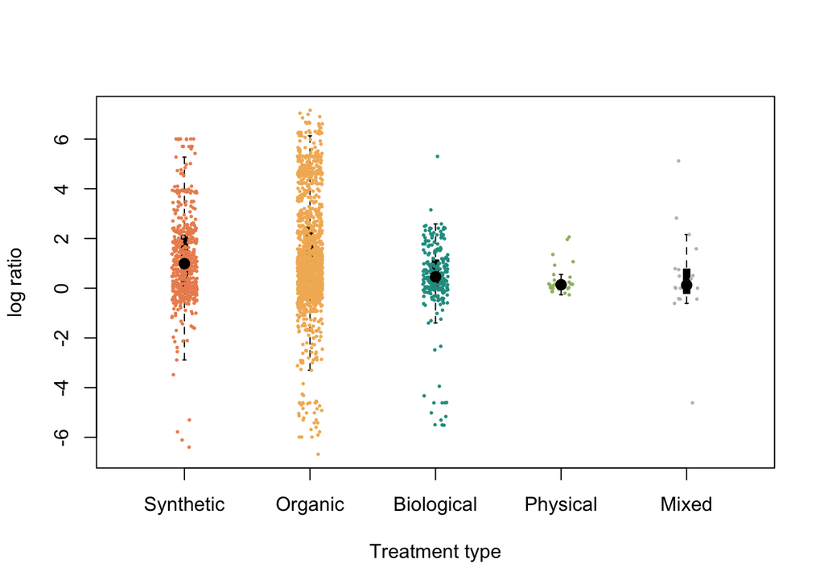

```r
plot(Full_comb_data$logratio ~ Full_comb_data$chem_split,
     col ="black",
     bty = "n",
     boxwex = 0.05,
     ylab = "log ratio",
     xlab = "Treatment type",
     pch = 16,
     cex = 0,
     names = c("Synthetic", "Organic", "Biological", "Physical", "Mixed"))

#We can plot the points for Synthetic
points(Full_comb_data[Full_comb_data$chem_split == "Synthetic", "logratio"] ~ jitter(as.integer(Full_comb_data[Full_comb_data$chem_split == "Synthetic",                                           "chem_split"]),
                  amount = 0.1),
       pch = 16,
       col = rgb(236, 143, 94, max=255),
       cex = 0.4)

points(median(Full_comb_data[Full_comb_data$chem_split == "Synthetic", "logratio"])
       ~ c(1),
       pch = 16,
       col = "black",
       cex = 1.3)


#We can plot the points for Agriculturally_Organic
points(Full_comb_data[Full_comb_data$chem_split == "Agriculturally_Organic",
                      "logratio"] ~
         jitter(as.integer(Full_comb_data[Full_comb_data$chem_split ==
                                            "Agriculturally_Organic",                                           "chem_split"]),
       amount = 0.1),
       pch = 16,
       col = rgb(243, 182, 100, max=255),
       cex = 0.4)

points(median(Full_comb_data[Full_comb_data$chem_split == "Agriculturally_Organic",
                             "logratio"]) ~ c(2),
       pch = 16,
       col = "black",
       cex = 1.3)

#We can plot the points for Biological
points(Full_comb_data[Full_comb_data$chem_split == "Biological", "logratio"] ~ jitter(as.integer(Full_comb_data[Full_comb_data$chem_split == "Biological",                                           "chem_split"]),
                  amount = 0.1),
       pch = 16,
       col = rgb(33, 156, 144, max=255),
       cex = 0.4)

points(median(Full_comb_data[Full_comb_data$chem_split == "Biological", "logratio"])
       ~ c(3),
       pch = 16,
       col = "black",
       cex = 1.3)



#We can plot the points for Physical
points(Full_comb_data[Full_comb_data$chem_split == "Physical", "logratio"] ~ jitter(as.integer(Full_comb_data[Full_comb_data$chem_split == "Physical",                                           "chem_split"]),
                  amount = 0.1),
       pch = 16,
       col = rgb(159, 187, 115, max=255),
       cex = 0.4)


points(median(Full_comb_data[Full_comb_data$chem_split == "Physical", "logratio"])
       ~ c(4),
       pch = 16,
       col = "black",
       cex = 1.3)


#We can plot the points for Mixed
points(Full_comb_data[Full_comb_data$chem_split == "Mixed", "logratio"] ~ jitter(as.integer(Full_comb_data[Full_comb_data$chem_split == "Mixed",                                           "chem_split"]),
                  amount = 0.1),
       pch = 16,
       col = "grey",
       cex = 0.4)

points(median(Full_comb_data[Full_comb_data$chem_split == "Mixed", "logratio"])
       ~ c(5),
       pch = 16,
       col = "black",
       cex = 1.3)
```

Both Physical and Mixed treatments are found to have reduced effects on outcomes when compared to synthetic chemicals, however neither are significantly different.

## Main model with bee breed included

We now run the model with studies that have defined the breed of bee.

```r
Full_breed <-  Full_comb_data[Full_comb_data$Lineage != "Apis_mellifera",]

mod_full_breed <- MCMCglmm(logratio ~ chem_split
                                + Context
                                + Lineage,
                                 rcov=~units,
                                 random =~StudyID_control
                                          + Continent
                                          + Cont_Country,
                                 family ="gaussian",
                                 data = Full_breed,
                                 nitt = nitt,
                                 thin = thining,
                                 burnin = burnin,
                                 prior = prior_d,
                                 verbose = F
                            )

#second model acts as second chain for convergence
#Add a 3rd later for final check
mod_full_breed2 <- MCMCglmm(logratio ~ chem_split
                                + Context
                                + Lineage,
                                 rcov=~units,
                                 random =~StudyID_control
                                          + Continent
                                          + Cont_Country,
                                 family ="gaussian",
                                 data = Full_breed,
                                 nitt = nitt,
                                 thin = thining,
                                 burnin = burnin,
                                 prior = prior_d,
                                 verbose = F
                            )


mod_full_breed3 <- MCMCglmm(logratio ~ chem_split
                                + Context
                                + Lineage,
                                 rcov=~units,
                                 random =~StudyID_control
                                          + Continent
                                          + Cont_Country,
                                 family ="gaussian",
                                 data = Full_breed,
                                 nitt = nitt,
                                 thin = thining,
                                 burnin = burnin,
                                 prior = prior_d,
                                 verbose = F
                            )


summary(mod_full_breed)
```

```
##
##  Iterations = 10001:109951
##  Thinning interval  = 50
##  Sample size  = 2000
##
##  DIC: 1363.306
##
##  G-structure:  ~StudyID_control
##
##                 post.mean l-95% CI u-95% CI eff.samp
## StudyID_control     1.158   0.3872    2.148     1836
##
##                ~Continent
##
##           post.mean  l-95% CI u-95% CI eff.samp
## Continent     13.49 1.571e-08    9.487     2000
##
##                ~Cont_Country
##
##              post.mean  l-95% CI u-95% CI eff.samp
## Cont_Country    0.2931 1.427e-07     1.14     1798
##
##  R-structure:  ~units
##
##       post.mean l-95% CI u-95% CI eff.samp
## units      1.27     1.09     1.44     2273
##
##  Location effects: logratio ~ chem_split + Context + Lineage
##
##                                  post.mean l-95% CI u-95% CI eff.samp pMCMC
## (Intercept)                        0.61698 -3.05979  3.64074     2000 0.664
## chem_splitAgriculturally_Organic   0.33554 -0.04717  0.76146     2000 0.100
## chem_splitBiological               0.20540 -2.39020  2.79687     2000 0.865
## chem_splitPhysical                 0.21940 -2.32187  2.58234     2000 0.843
## chem_splitMixed                    0.10057 -3.17334  3.28618     2000 0.963
## ContextLab                         0.78196 -0.12252  1.71530     2082 0.094 .
## LineageAf_lineage                  0.14326 -4.29946  5.60478     2171 0.943
## LineageBuck_lineage               -0.89894 -4.89679  3.82830     2000 0.557
## LineageC_lineage                  -0.51667 -4.26665  3.13680     2000 0.710
## LineageO_lineage                  -0.34848 -4.37654  3.26968     2000 0.810
## ---
## Signif. codes:  0 '***' 0.001 '**' 0.01 '*' 0.05 '.' 0.1 ' ' 1
```

```r
#Check the fixed terms
mainB_Sol_conv <- gelman.diag(mcmc.list(mod_full_breed$Sol,
                                       mod_full_breed2$Sol,
                                       mod_full_breed3$Sol))
mainB_Sol_conv
```

```
## Potential scale reduction factors:
##
##                                  Point est. Upper C.I.
## (Intercept)                               1       1.00
## chem_splitAgriculturally_Organic          1       1.00
## chem_splitBiological                      1       1.00
## chem_splitPhysical                        1       1.00
## chem_splitMixed                           1       1.00
## ContextLab                                1       1.01
## LineageAf_lineage                         1       1.00
## LineageBuck_lineage                       1       1.00
## LineageC_lineage                          1       1.00
## LineageO_lineage                          1       1.00
##
## Multivariate psrf
##
## 1
```

```r
#Check the random terms
mainB_VCV_conv <- gelman.diag(mcmc.list(mod_full_breed$VCV,
                                       mod_full_breed2$VCV,
                                       mod_full_breed3$VCV))
mainB_VCV_conv
```

```
## Potential scale reduction factors:
##
##                 Point est. Upper C.I.
## StudyID_control       1.00       1.00
## Continent             1.20       1.21
## Cont_Country          1.03       1.03
## units                 1.00       1.00
##
## Multivariate psrf
##
## 1
```

# Main model with effects just on bees

We can also repeat the main model with just bees included. This is with both increases and decreases combined but with the decreases pop data sign flipped so now any positive value is also a posative indicator for bee population or health.

```r
All_bees_data <- rbind(HoneyBeeReduction_paired_red_fin,
                       HoneyBeeIncrease_paired_fin)



mod_all_bees <- MCMCglmm(logratio ~ chem_split
                                  + Context,
                                 rcov=~units,
                                 random =~StudyID_control
                                          + Continent
                                          + Cont_Country,
                                 family ="gaussian",
                                 data = All_bees_data,
                                 nitt = nitt,
                                 thin = thining,
                                 burnin = burnin,
                                 prior = prior_d,
                                 verbose = FALSE
                            )



mod_all_bees2 <- MCMCglmm(logratio ~ chem_split
                          + Context,
                                 rcov=~units,
                                 random =~StudyID_control
                                          + Continent
                                          + Cont_Country,
                                 family ="gaussian",
                                 data = All_bees_data,
                                 nitt = nitt,
                                 thin = thining,
                                 burnin = burnin,
                                 prior = prior_d,
                                 verbose = FALSE
                            )


mod_all_bees3 <- MCMCglmm(logratio ~ chem_split
                          + Context,
                                 rcov=~units,
                                 random =~StudyID_control
                                          + Continent
                                          + Cont_Country,
                                 family ="gaussian",
                                 data = All_bees_data,
                                 nitt = nitt,
                                 thin = thining,
                                 burnin = burnin,
                                 prior = prior_d,
                                 verbose = FALSE
                            )

#Check the fixed terms
mod_all_bees_Sol_conv <- gelman.diag(mcmc.list(mod_all_bees$Sol,
                                               mod_all_bees2$Sol,
                                               mod_all_bees3$Sol))
mod_all_bees_Sol_conv
```

```
## Potential scale reduction factors:
##
##                                  Point est. Upper C.I.
## (Intercept)                               1       1.01
## chem_splitAgriculturally_Organic          1       1.00
## chem_splitBiological                      1       1.00
## chem_splitPhysical                        1       1.00
## chem_splitMixed                           1       1.00
## ContextLab                                1       1.00
##
## Multivariate psrf
##
## 1
```

```r
#Check the random terms
mod_all_bees_VCV_conv <- gelman.diag(mcmc.list(mod_all_bees$VCV,
                                               mod_all_bees2$VCV,
                                               mod_all_bees3$VCV))
mod_all_bees_VCV_conv
```

```
## Potential scale reduction factors:
##
##                 Point est. Upper C.I.
## StudyID_control        1.0       1.00
## Continent              1.1       1.11
## Cont_Country           1.0       1.00
## units                  1.0       1.00
##
## Multivariate psrf
##
## 1
```

```r
summary(mod_all_bees)
```

```
##
##  Iterations = 10001:109951
##  Thinning interval  = 50
##  Sample size  = 2000
##
##  DIC: 2506.151
##
##  G-structure:  ~StudyID_control
##
##                 post.mean l-95% CI u-95% CI eff.samp
## StudyID_control     1.272   0.7974    1.833     1847
##
##                ~Continent
##
##           post.mean l-95% CI u-95% CI eff.samp
## Continent    0.1812 1.96e-07   0.7152     1863
##
##                ~Cont_Country
##
##              post.mean  l-95% CI u-95% CI eff.samp
## Cont_Country   0.06527 3.509e-09   0.2606     2000
##
##  R-structure:  ~units
##
##       post.mean l-95% CI u-95% CI eff.samp
## units     1.346    1.219     1.49     2000
##
##  Location effects: logratio ~ chem_split + Context
##
##                                  post.mean l-95% CI u-95% CI eff.samp pMCMC
## (Intercept)                       -0.61557 -1.22243 -0.06854     2000 0.046 *
## chem_splitAgriculturally_Organic   0.27857 -0.02975  0.59841     1852 0.082 .
## chem_splitBiological               0.45279 -0.25919  1.16770     1537 0.208
## chem_splitPhysical                 0.55584 -0.89496  1.94696     2000 0.435
## chem_splitMixed                    0.65712 -1.08429  2.49845     1801 0.484
## ContextLab                        -0.19132 -0.79923  0.41826     2000 0.549
## ---
## Signif. codes:  0 '***' 0.001 '**' 0.01 '*' 0.05 '.' 0.1 ' ' 1
```

We can do a simple plot of our results.

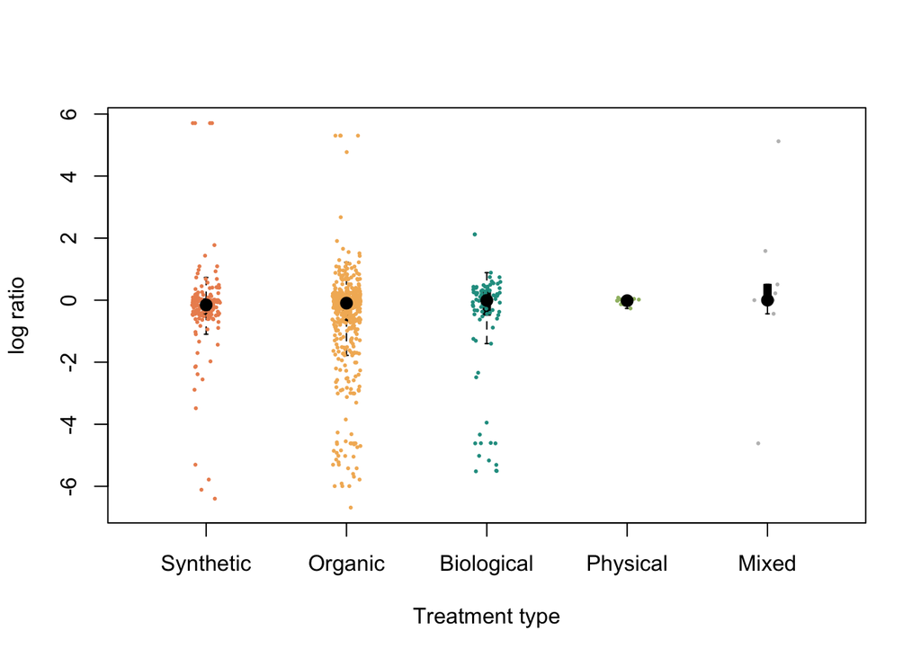

```r
plot(All_bees_data$logratio ~ All_bees_data$chem_split,
     col ="black",
     bty = "n",
     boxwex = 0.05,
     ylab = "log ratio",
     xlab = "Treatment type",
     pch = 16,
     cex = 0,
     names = c("Synthetic", "Organic", "Biological", "Physical", "Mixed"))

#We can plot the points for Synthetic
points(All_bees_data[All_bees_data$chem_split == "Synthetic", "logratio"] ~ jitter(as.integer(All_bees_data[All_bees_data$chem_split == "Synthetic",                                           "chem_split"]),
                  amount = 0.1),
       pch = 16,
       col = rgb(236, 143, 94, max=255),
       cex = 0.4)

points(median(All_bees_data[All_bees_data$chem_split == "Synthetic", "logratio"])
       ~ c(1),
       pch = 16,
       col = "black",
       cex = 1.3)


#We can plot the points for Agriculturally_Organic
points(All_bees_data[All_bees_data$chem_split == "Agriculturally_Organic", "logratio"] ~ jitter(as.integer(All_bees_data[All_bees_data$chem_split == "Agriculturally_Organic",                                           "chem_split"]),
                  amount = 0.1),
       pch = 16,
       col = rgb(243, 182, 100, max=255),
       cex = 0.4)


points(median(All_bees_data[All_bees_data$chem_split == "Agriculturally_Organic",
                            "logratio"])
       ~ c(2),
       pch = 16,
       col = "black",
       cex = 1.3)



#We can plot the points for Biological
points(All_bees_data[All_bees_data$chem_split == "Biological", "logratio"] ~ jitter(as.integer(All_bees_data[All_bees_data$chem_split == "Biological",                                           "chem_split"]),
                  amount = 0.1),
       pch = 16,
       col = rgb(33, 156, 144, max=255),
       cex = 0.4)

points(median(All_bees_data[All_bees_data$chem_split == "Biological",
                            "logratio"])
       ~ c(3),
       pch = 16,
       col = "black",
       cex = 1.3)



#We can plot the points for Physical
points(All_bees_data[All_bees_data$chem_split == "Physical", "logratio"] ~ jitter(as.integer(All_bees_data[All_bees_data$chem_split == "Physical",                                           "chem_split"]),
                  amount = 0.1),
       pch = 16,
       col = rgb(159, 187, 115, max=255),
       cex = 0.4)


points(median(All_bees_data[All_bees_data$chem_split == "Physical",
                            "logratio"])
       ~ c(4),
       pch = 16,
       col = "black",
       cex = 1.3)



#We can plot the points for Mixed
points(All_bees_data[All_bees_data$chem_split == "Mixed", "logratio"] ~ jitter(as.integer(All_bees_data[All_bees_data$chem_split == "Mixed",
                                                     "chem_split"]),
                                                      amount = 0.1),
                                                      pch = 16,
                                                      col = "grey",
                                                      cex = 0.4)

points(median(All_bees_data[All_bees_data$chem_split == "Mixed",
                            "logratio"])
       ~ c(5),
       pch = 16,
       col = "black",
       cex = 1.3)
```

# Main model with effects just on Varrora

We can also do the main model with just Varroa data included. Here we include both studies that measure increases or decreases in Varroa population or health data. Again the log ratio is calculated so that a positive value indicates a positive outcome for bee health/populations (that is a reduction in Varroa is indicated in positive terms.).

```r
All_varroa_data <- rbind(VarroaReduction_paired_fin,
                       VarroaIncrease_paired_red_fin)

All_varroa_data_mod <- MCMCglmm(logratio ~ chem_split
                                + Context,
                                 rcov=~units,
                                 random =~StudyID_control
                                          + Continent
                                          + Cont_Country,
                                 family ="gaussian",
                                 data = All_varroa_data,
                                 nitt = nitt,
                                 thin = thining,
                                 burnin = burnin,
                                 prior = prior_d,
                                 verbose = FALSE
                            )


All_varroa_data_mod2 <- MCMCglmm(logratio ~ chem_split
                                 + Context,
                                 rcov=~units,
                                 random =~StudyID_control
                                          + Continent
                                          + Cont_Country,
                                 family ="gaussian",
                                 data = All_varroa_data,
                                 nitt = nitt,
                                 thin = thining,
                                 burnin = burnin,
                                 prior = prior_d,
                                 verbose = FALSE
                            )

All_varroa_data_mod3 <- MCMCglmm(logratio ~ chem_split
                                 + Context,
                                 rcov=~units,
                                 random =~StudyID_control
                                          + Continent
                                          + Cont_Country,
                                 family ="gaussian",
                                 data = All_varroa_data,
                                 nitt = nitt,
                                 thin = thining,
                                 burnin = burnin,
                                 prior = prior_d,
                                 verbose = FALSE
                            )


#Check the fixed terms
All_varroa_data_mod_Sol_conv <- gelman.diag(mcmc.list(All_varroa_data_mod$Sol,
                                               All_varroa_data_mod2$Sol,
                                               All_varroa_data_mod3$Sol))
All_varroa_data_mod_Sol_conv
```

```
## Potential scale reduction factors:
##
##                                  Point est. Upper C.I.
## (Intercept)                               1          1
## chem_splitAgriculturally_Organic          1          1
## chem_splitBiological                      1          1
## chem_splitPhysical                        1          1
## chem_splitMixed                           1          1
## ContextLab                                1          1
##
## Multivariate psrf
##
## 1
```

```r
#Check the random terms
All_varroa_data_mod_VCV_conv <- gelman.diag(mcmc.list(All_varroa_data_mod$VCV,
                                               All_varroa_data_mod2$VCV,
                                               All_varroa_data_mod3$VCV))
All_varroa_data_mod_VCV_conv
```

```
## Potential scale reduction factors:
##
##                 Point est. Upper C.I.
## StudyID_control       1.00       1.00
## Continent             1.06       1.06
## Cont_Country          1.01       1.01
## units                 1.00       1.00
##
## Multivariate psrf
##
## 1
```

```r
summary(All_varroa_data_mod)
```

```
##
##  Iterations = 10001:109951
##  Thinning interval  = 50
##  Sample size  = 2000
##
##  DIC: 5750.444
##
##  G-structure:  ~StudyID_control
##
##                 post.mean l-95% CI u-95% CI eff.samp
## StudyID_control    0.9909   0.7194    1.308     2000
##
##                ~Continent
##
##           post.mean l-95% CI u-95% CI eff.samp
## Continent    0.1055 3.75e-10   0.4373     1681
##
##                ~Cont_Country
##
##              post.mean l-95% CI u-95% CI eff.samp
## Cont_Country   0.04927 3.05e-09    0.188     2000
##
##  R-structure:  ~units
##
##       post.mean l-95% CI u-95% CI eff.samp
## units     1.671    1.546    1.782     2000
##
##  Location effects: logratio ~ chem_split + Context
##
##                                  post.mean l-95% CI u-95% CI eff.samp  pMCMC
## (Intercept)                        1.59866  1.16722  2.00812     2000 <5e-04
## chem_splitAgriculturally_Organic   0.07136 -0.19348  0.32020     2000  0.583
## chem_splitBiological              -0.77002 -1.25326 -0.31745     2000  0.001
## chem_splitPhysical                -0.81014 -1.82775  0.18590     2000  0.125
## chem_splitMixed                   -0.53593 -1.87702  0.80136     2000  0.452
## ContextLab                         0.44851  0.14655  0.78291     2000  0.008
##
## (Intercept)                      ***
## chem_splitAgriculturally_Organic
## chem_splitBiological             ***
## chem_splitPhysical
## chem_splitMixed
## ContextLab                       **
## ---
## Signif. codes:  0 '***' 0.001 '**' 0.01 '*' 0.05 '.' 0.1 ' ' 1
```

We can do a simple plot of our results.

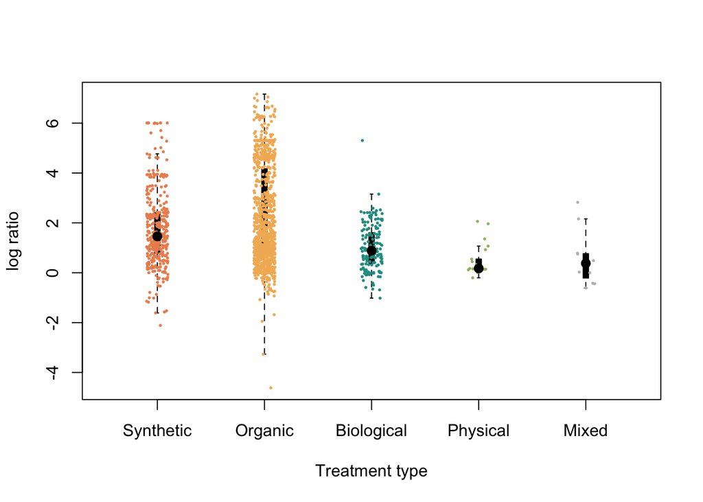

```r
plot(All_varroa_data$logratio ~ All_varroa_data$chem_split,
     col ="black",
     bty = "n",
     boxwex = 0.05,
     ylab = "log ratio",
     xlab = "Treatment type",
     pch = 16,
     cex = 0,
    names = c("Synthetic", "Organic", "Biological", "Physical", "Mixed"))

#We can plot the points for Synthetic
points(All_varroa_data[All_varroa_data$chem_split == "Synthetic", "logratio"] ~ jitter(as.integer(All_varroa_data[All_varroa_data$chem_split == "Synthetic",                                           "chem_split"]),
                  amount = 0.1),
       pch = 16,
       col = rgb(236, 143, 94, max=255),
       cex = 0.4)

points(median(All_varroa_data[All_varroa_data$chem_split == "Synthetic",
                            "logratio"])
       ~ c(1),
       pch = 16,
       col = "black",
       cex = 1.3)


#We can plot the points for Agriculturally_Organic
points(All_varroa_data[All_varroa_data$chem_split == "Agriculturally_Organic",
                       "logratio"]
       ~ jitter(as.integer(All_varroa_data[All_varroa_data$chem_split ==
                                             "Agriculturally_Organic",
                                           "chem_split"]),
                                            amount = 0.1),
                                            pch = 16,
                                            col = rgb(243, 182, 100, max=255),
                                            cex = 0.4)

points(median(All_varroa_data[All_varroa_data$chem_split == "Agriculturally_Organic",
                            "logratio"])
       ~ c(2),
       pch = 16,
       col = "black",
       cex = 1.3)



#We can plot the points for Biological
points(All_varroa_data[All_varroa_data$chem_split == "Biological", "logratio"] ~ jitter(as.integer(All_varroa_data[All_varroa_data$chem_split == "Biological",                                           "chem_split"]),
                  amount = 0.1),
       pch = 16,
       col = rgb(33, 156, 144, max=255),
       cex = 0.4)

points(median(All_varroa_data[All_varroa_data$chem_split == "Biological",
                            "logratio"])
       ~ c(3),
       pch = 16,
       col = "black",
       cex = 1.3)


#We can plot the points for Physical
points(All_varroa_data[All_varroa_data$chem_split == "Physical", "logratio"] ~ jitter(as.integer(All_varroa_data[All_varroa_data$chem_split == "Physical",                                           "chem_split"]),
                  amount = 0.1),
       pch = 16,
       col = rgb(159, 187, 115, max=255),
       cex = 0.4)

points(median(All_varroa_data[All_varroa_data$chem_split == "Physical",
                            "logratio"])
       ~ c(4),
       pch = 16,
       col = "black",
       cex = 1.3)



#We can plot the points for Mixed
points(All_varroa_data[All_varroa_data$chem_split == "Mixed", "logratio"] ~ jitter(as.integer(All_varroa_data[All_varroa_data$chem_split == "Mixed",
                                                     "chem_split"]),
                                                      amount = 0.1),
                                                      pch = 16,
                                                      col = "grey",
                                                      cex = 0.4)

points(median(All_varroa_data[All_varroa_data$chem_split == "Mixed",
                            "logratio"])
       ~ c(5),
       pch = 16,
       col = "black",
       cex = 1.3)
```

# Chemical treatment sub analysis

# Dosage dependance

Taking from the Full_comb_data, which has the signs flipped so any positive number is a positive effect for bees (i.e. decreased bee mortality is now a positive number) we create a subset for data that has some measure of dosage. To allow for comparisons we include dosage as low medium high as either described in the paper.

```r
Full_dosage <- data.frame(logratio = Full_comb_data$logratio,
                          StudyID = Full_comb_data$StudyID,
                          SubCa2Treat = Full_comb_data$SubCategory2Treatment,
                          Dosage_level = factor(Full_comb_data$Dosage_level),
                          Continent = Full_comb_data$Continent,
                          Country = Full_comb_data$Country,
                          Cont_Country = Full_comb_data$Cont_Country,
                          Context = Full_comb_data$Context)

Full_dosage <- na.omit(Full_dosage)
```

Ordinal dosage analysis.

```r
mod_dos <- MCMCglmm(logratio ~ Dosage_level + Context,
                                 rcov=~units,
                                 random =~StudyID,
                                 family ="gaussian",
                                 data = Full_dosage,
                                 nitt = nitt,
                                 thin = thining,
                                 burnin = burnin,
                                 verbose = FALSE
                            )

mod_dos2 <- MCMCglmm(logratio ~ Dosage_level + Context,
                                 rcov=~units,
                                 random =~StudyID ,
                                 family ="gaussian",
                                 data = Full_dosage,
                                 nitt = nitt,
                                 thin = thining,
                                 burnin = burnin,
                                 verbose = FALSE
                            )

mod_dos3 <- MCMCglmm(logratio ~ Dosage_level + Context,
                                 rcov=~units,
                                 random =~StudyID ,
                                 family ="gaussian",
                                 data = Full_dosage,
                                 nitt = nitt,
                                 thin = thining,
                                 burnin = burnin,
                                 verbose = FALSE
                            )


#Check the fixed terms
mod_dos_Sol_conv <- gelman.diag(mcmc.list(mod_dos$Sol,
                                               mod_dos2$Sol,
                                               mod_dos3$Sol))
mod_dos_Sol_conv
```

```
## Potential scale reduction factors:
##
##                    Point est. Upper C.I.
## (Intercept)                 1          1
## Dosage_levelLOW             1          1
## Dosage_levelMEDIUM          1          1
## ContextLab                  1          1
##
## Multivariate psrf
##
## 1
```

```r
#Check the random terms
mod_dos_VCV_conv <- gelman.diag(mcmc.list(mod_dos$VCV,
                                               mod_dos2$VCV,
                                               mod_dos3$VCV))
mod_dos_VCV_conv
```

```
## Potential scale reduction factors:
##
##         Point est. Upper C.I.
## StudyID          1       1.01
## units            1       1.00
##
## Multivariate psrf
##
## 1
```

```r
summary(mod_dos)
```

```
##
##  Iterations = 10001:109951
##  Thinning interval  = 50
##  Sample size  = 2000
##
##  DIC: 853.8264
##
##  G-structure:  ~StudyID
##
##         post.mean l-95% CI u-95% CI eff.samp
## StudyID    0.6744   0.2003    1.277     2000
##
##  R-structure:  ~units
##
##       post.mean l-95% CI u-95% CI eff.samp
## units     1.639    1.335    1.953     2000
##
##  Location effects: logratio ~ Dosage_level + Context
##
##                    post.mean l-95% CI u-95% CI eff.samp  pMCMC
## (Intercept)           1.1172   0.6263   1.6248     1840 <5e-04 ***
## Dosage_levelLOW      -0.1987  -0.5442   0.1693     2000  0.267
## Dosage_levelMEDIUM    0.1869  -0.3046   0.6927     2000  0.454
## ContextLab           -0.1149  -0.9110   0.5838     2185  0.760
## ---
## Signif. codes:  0 '***' 0.001 '**' 0.01 '*' 0.05 '.' 0.1 ' ' 1
```

We can do a simple plot of our results.

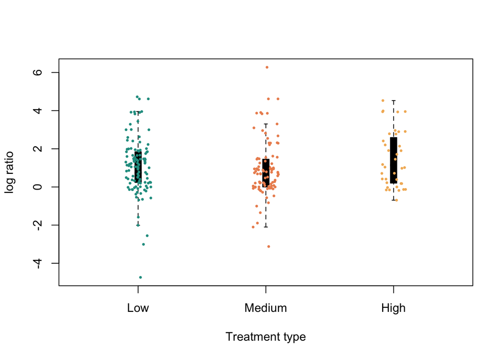

```r
plot(Full_dosage$logratio ~ factor(Full_dosage$Dosage_level),
     col ="black",
     bty = "n",
     boxwex = 0.05,
     ylab = "log ratio",
     xlab = "Treatment type",
     pch = 16,
     cex = 0,
     names = c("Low", "Medium", "High"))

#We can plot the points for LOW
points(Full_dosage[Full_dosage$Dosage_level == "LOW", "logratio"] ~
         jitter(as.integer(Full_dosage[Full_dosage$Dosage_level == "LOW",
                                       "Dosage_level"]),
                  amount = 0.1),
       pch = 16,
       col = rgb(236, 143, 94, max=255),
       cex = 0.5)

points(median(Full_dosage[Full_dosage$Dosage_level == "LOW", "logratio"])
       ~ c(1),
       pch = 16,
       col = "black",
       cex = 1.3)


#We can plot the points for MEDIUM
points(Full_dosage[Full_dosage$Dosage_level == "MEDIUM", "logratio"] ~
         jitter(as.integer(Full_dosage[Full_dosage$Dosage_level == "MEDIUM",
                                       "Dosage_level"]),
       amount = 0.1),
       pch = 16,
       col = rgb(243, 182, 100, max=255),
       cex = 0.5)

points(median(Full_dosage[Full_dosage$Dosage_level == "MEDIUM", "logratio"])
       ~ c(2),
       pch = 16,
       col = "black",
       cex = 1.3)

#We can plot the points for HIGH
points(Full_dosage[Full_dosage$Dosage_level == "HIGH", "logratio"] ~
         jitter(as.integer(Full_dosage[Full_dosage$Dosage_level == "HIGH",                                           "Dosage_level"]),
                  amount = 0.1),
       pch = 16,
       col = rgb(33, 156, 144, max=255),
       cex = 0.5)

points(median(Full_dosage[Full_dosage$Dosage_level == "HIGH", "logratio"])
       ~ c(3),
       pch = 16,
       col = "black",
       cex = 1.3)
```

# break down each of the chemicals

We can compare each of the specific chemicals for which we had enough data.

```r
temp_Sub_chem <- Full_comb_data

#combine Flumethrin and Fluvalinate and call them Pyrethroid
temp_Sub_chem[temp_Sub_chem$broadTreatment %in% c("Flumethrin",
                                                  "Fluvalinate"),
              "broadTreatment"] <- "Pyrethroid"

Sub_chem <- temp_Sub_chem[temp_Sub_chem$broadTreatment %in%
c("Amitraz",
  "Coumaphos",
  "Thymol",
  "Oxalic_acid",
  "Formic_acid",
  "Pyrethroid"), ]

Sub_chem$broadTreatment <- factor(Sub_chem$broadTreatment)
```

We can now run the model comparing each of the size chemical groups to a baseline. We use Amitraz as the baseline here as its got a large sample size and as its one of the most effective trreatments making the contrasts a little easier to interpreate.

```r
mod_spec_chem <- MCMCglmm(logratio ~ broadTreatment + Context,
                                 rcov=~units,
                                 random =~StudyID
                                          + Continent
                                          + Cont_Country,
                                 family ="gaussian",
                                 data = Sub_chem,
                                 nitt = nitt,
                                 thin = thining,
                                 burnin = burnin,
                                 prior = prior_d,
                                 verbose = FALSE
                            )

mod_spec_chem2 <- MCMCglmm(logratio ~ broadTreatment + Context,
                                 rcov=~units,
                                 random =~StudyID
                                          + Continent
                                          + Cont_Country,
                                 family ="gaussian",
                                 data = Sub_chem,
                                 nitt = nitt,
                                 thin = thining,
                                 burnin = burnin,
                                 prior = prior_d,
                                 verbose = FALSE
                            )


mod_spec_chem3 <- MCMCglmm(logratio ~ broadTreatment + Context,
                                 rcov=~units,
                                 random =~StudyID
                                          + Continent
                                          + Cont_Country,
                                 family ="gaussian",
                                 data = Sub_chem,
                                 nitt = nitt,
                                 thin = thining,
                                 burnin = burnin,
                                 prior = prior_d,
                                 verbose = FALSE
                            )



#Check the fixed terms
mod_spec_chem_Sol_conv <- gelman.diag(mcmc.list(mod_spec_chem$Sol,
                                               mod_spec_chem2$Sol,
                                               mod_spec_chem3$Sol))
mod_spec_chem_Sol_conv
```

```
## Potential scale reduction factors:
##
##                           Point est. Upper C.I.
## (Intercept)                        1          1
## broadTreatmentCoumaphos            1          1
## broadTreatmentFormic_acid          1          1
## broadTreatmentOxalic_acid          1          1
## broadTreatmentPyrethroid           1          1
## broadTreatmentThymol               1          1
## ContextLab                         1          1
##
## Multivariate psrf
##
## 1
```

```r
#Check the random terms
mod_spec_chem_VCV_conv <- gelman.diag(mcmc.list(mod_spec_chem$VCV,
                                               mod_spec_chem2$VCV,
                                               mod_spec_chem3$VCV))
mod_spec_chem_VCV_conv
```

```
## Potential scale reduction factors:
##
##              Point est. Upper C.I.
## StudyID            1.00       1.00
## Continent          1.02       1.02
## Cont_Country       1.00       1.00
## units              1.00       1.01
##
## Multivariate psrf
##
## 1
```

```r
summary(mod_spec_chem)
```

```
##
##  Iterations = 10001:109951
##  Thinning interval  = 50
##  Sample size  = 2000
##
##  DIC: 3511.809
##
##  G-structure:  ~StudyID
##
##         post.mean l-95% CI u-95% CI eff.samp
## StudyID    0.4213   0.1914   0.6593     2000
##
##                ~Continent
##
##           post.mean  l-95% CI u-95% CI eff.samp
## Continent    0.5674 7.085e-08    2.273     2000
##
##                ~Cont_Country
##
##              post.mean l-95% CI u-95% CI eff.samp
## Cont_Country    0.1999 5.57e-08    0.582     1669
##
##  R-structure:  ~units
##
##       post.mean l-95% CI u-95% CI eff.samp
## units     1.964     1.79    2.143     2000
##
##  Location effects: logratio ~ broadTreatment + Context
##
##                           post.mean  l-95% CI  u-95% CI eff.samp  pMCMC
## (Intercept)                1.339602  0.554999  2.151776     2000  0.006 **
## broadTreatmentCoumaphos   -1.048355 -1.517309 -0.568255     2000 <5e-04 ***
## broadTreatmentFormic_acid -0.317712 -0.699127  0.079088     2184  0.123
## broadTreatmentOxalic_acid -0.226061 -0.686537  0.282443     2000  0.345
## broadTreatmentPyrethroid  -0.293826 -0.625801  0.091748     2000  0.116
## broadTreatmentThymol      -0.155641 -0.500947  0.225142     2000  0.403
## ContextLab                 0.553583 -0.009425  1.041797     2000  0.047 *
## ---
## Signif. codes:  0 '***' 0.001 '**' 0.01 '*' 0.05 '.' 0.1 ' ' 1
```

We can do a simple plot of our results.

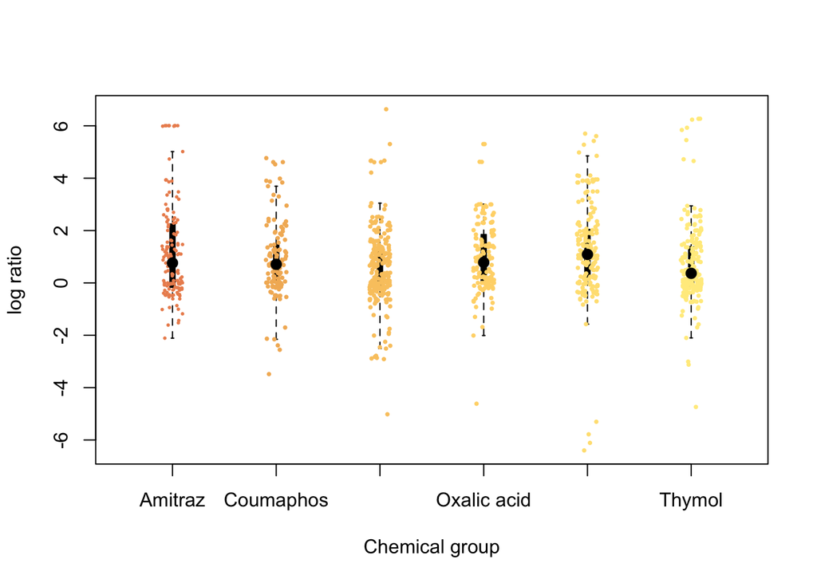

```r
plot(Sub_chem$logratio ~ Sub_chem$broadTreatment,
     col ="black",
     bty = "n",
     boxwex = 0.05,
     ylab = "log ratio",
     xlab = "Chemical group",
     pch = 16,
     cex = 0,
     names = c("Amitraz",
               "Coumaphos",
               "Formic acid",
               "Oxalic acid",
               "Pyrethroid",
               "Thymol"))

#We can plot the points for Amitraz
points(Sub_chem[Sub_chem$broadTreatment == "Amitraz", "logratio"] ~
         jitter(as.integer(Sub_chem[Sub_chem$broadTreatment == "Amitraz",
                                    "broadTreatment"]),
                  amount = 0.1),
       pch = 16,
       col = rgb(236, 143, 94, max=255),
       cex = 0.4)

points(median(Sub_chem[Sub_chem$broadTreatment == "Amitraz", "logratio"])
       ~ c(1),
       pch = 16,
       col = "black",
       cex = 1.3)



#We can plot the points for Coumaphos
points(Sub_chem[Sub_chem$broadTreatment == "Coumaphos", "logratio"] ~
         jitter(as.integer(Sub_chem[Sub_chem$broadTreatment == "Coumaphos",
                                    "broadTreatment"]),amount = 0.1),
       pch = 16,col = rgb(243, 182, 100, max=255),
       cex = 0.5)

points(median(Sub_chem[Sub_chem$broadTreatment == "Coumaphos", "logratio"])
       ~ c(2),
       pch = 16,
       col = "black",
       cex = 1.3)



#We can plot the points for Formic_acid
points(Sub_chem[Sub_chem$broadTreatment == "Formic_acid", "logratio"] ~
         jitter(as.integer(Sub_chem[Sub_chem$broadTreatment == "Formic_acid",
                                    "broadTreatment"]),amount = 0.1),
       pch = 16,
       col = rgb(250, 200, 110, max=255),
       cex = 0.5)

points(median(Sub_chem[Sub_chem$broadTreatment == "Formic_acid", "logratio"])
       ~ c(3),
       pch = 16,
       col = "black",
       cex = 1.3)


#We can plot the points for Oxalic_acid
points(Sub_chem[Sub_chem$broadTreatment == "Oxalic_acid", "logratio"] ~
         jitter(as.integer(Sub_chem[Sub_chem$broadTreatment == "Oxalic_acid",
                                    "broadTreatment"]),
                  amount = 0.1),
       pch = 16,
       col = rgb(255, 215, 120, max=255),
       cex = 0.5)

points(median(Sub_chem[Sub_chem$broadTreatment == "Oxalic_acid", "logratio"])
       ~ c(4),
       pch = 16,
       col = "black",
       cex = 1.3)



#We can plot the points for Pyrethroid
points(Sub_chem[Sub_chem$broadTreatment == "Pyrethroid", "logratio"] ~
         jitter(as.integer(Sub_chem[Sub_chem$broadTreatment == "Pyrethroid",
                                    "broadTreatment"]),
                  amount = 0.1),
       pch = 16,
       col = rgb(255, 225, 130, max=255),
       cex = 0.5)

points(median(Sub_chem[Sub_chem$broadTreatment == "Pyrethroid", "logratio"])
       ~ c(5),
       pch = 16,
       col = "black",
       cex = 1.3)


#We can plot the points for Thymol
points(Sub_chem[Sub_chem$broadTreatment == "Thymol", "logratio"] ~
         jitter(as.integer(Sub_chem[Sub_chem$broadTreatment == "Thymol",
                                    "broadTreatment"]),
                  amount = 0.1),
       pch = 16,
       col = rgb(255, 235, 140, max=255),
       cex = 0.5)

points(median(Sub_chem[Sub_chem$broadTreatment == "Thymol", "logratio"])
       ~ c(6),
       pch = 16,
       col = "black",
       cex = 1.3)
```

# Biological

Lets look at the Biological sub category

```r
Full_bio <-  Full_comb_data[Full_comb_data$categoryTreatment == "Biological",]

Full_bio$SubCategory1Treatment <- factor(Full_bio$SubCategory1Treatment)

nitt_b <- 2200000
thining_b <- 1000
burnin_b <- 200000

 mod_Full_bio <- MCMCglmm(logratio ~ SubCategory1Treatment + Context,
                                 rcov=~units,
                                 random =~StudyID_control
                                          + Continent
                                          + Cont_Country,
                                 family ="gaussian",
                                 data = Full_bio,
                                 nitt = nitt_b,
                                 thin = thining_b,
                                 burnin = burnin_b,
                                 verbose = FALSE
                            )


mod_Full_bio2 <- MCMCglmm(logratio ~ SubCategory1Treatment + Context,
                                 rcov=~units,
                                 random =~StudyID_control
                                          + Continent
                                          + Cont_Country,
                                 family ="gaussian",
                                 data = Full_bio,
                                 nitt = nitt_b,
                                 thin = thining_b,
                                 burnin = burnin_b,
                                 verbose = FALSE
                            )


mod_Full_bio3 <- MCMCglmm(logratio ~ SubCategory1Treatment + Context,
                                 rcov=~units,
                                 random =~StudyID_control
                                          + Continent
                                          + Cont_Country,
                                 family ="gaussian",
                                 data = Full_bio,
                                 nitt = nitt_b,
                                 thin = thining_b,
                                 burnin = burnin_b,
                                 verbose = FALSE
                            )

#Check the fixed terms
mod_Full_bio_Sol_conv <- gelman.diag(mcmc.list(mod_Full_bio$Sol,
                                               mod_Full_bio2$Sol,
                                               mod_Full_bio3$Sol))
mod_Full_bio_Sol_conv
```

```
## Potential scale reduction factors:
##
##                                      Point est. Upper C.I.
## (Intercept)                                   1          1
## SubCategory1TreatmentNatural_enemies          1          1
## ContextLab                                    1          1
##
## Multivariate psrf
##
## 1
```

```r
#Check the random terms
mod_Full_bio_VCV_conv <- gelman.diag(mcmc.list(mod_Full_bio$VCV,
                                               mod_Full_bio2$VCV,
                                               mod_Full_bio3$VCV))
mod_Full_bio_VCV_conv
```

```
## Potential scale reduction factors:
##
##                 Point est. Upper C.I.
## StudyID_control       1.03       1.03
## Continent             1.11       1.11
## Cont_Country          1.02       1.02
## units                 1.00       1.00
##
## Multivariate psrf
##
## 1
```

```r
summary(mod_Full_bio)
```

```
##
##  Iterations = 200001:2199001
##  Thinning interval  = 1000
##  Sample size  = 2000
##
##  DIC: 877.3249
##
##  G-structure:  ~StudyID_control
##
##                 post.mean  l-95% CI u-95% CI eff.samp
## StudyID_control  0.002423 9.726e-17 0.008492     1646
##
##                ~Continent
##
##           post.mean  l-95% CI u-95% CI eff.samp
## Continent   0.01004 4.128e-17  0.03608     2000
##
##                ~Cont_Country
##
##              post.mean  l-95% CI u-95% CI eff.samp
## Cont_Country  0.007012 2.718e-17  0.02942     1683
##
##  R-structure:  ~units
##
##       post.mean l-95% CI u-95% CI eff.samp
## units     2.378    1.965    2.826     1740
##
##  Location effects: logratio ~ SubCategory1Treatment + Context
##
##                                      post.mean l-95% CI u-95% CI eff.samp pMCMC
## (Intercept)                            0.62100  0.06574  1.14514     2000 0.029
## SubCategory1TreatmentNatural_enemies  -0.04717 -0.66076  0.55592     2000 0.848
## ContextLab                            -0.53539 -0.98802 -0.12973     1874 0.023
##
## (Intercept)                          *
## SubCategory1TreatmentNatural_enemies
## ContextLab                           *
## ---
## Signif. codes:  0 '***' 0.001 '**' 0.01 '*' 0.05 '.' 0.1 ' ' 1
```

Here bee bread has a significant effect compared to the null of about 2/1 with no significant difference of the effect of Natural enemies.

We can do a simple plot of our results.

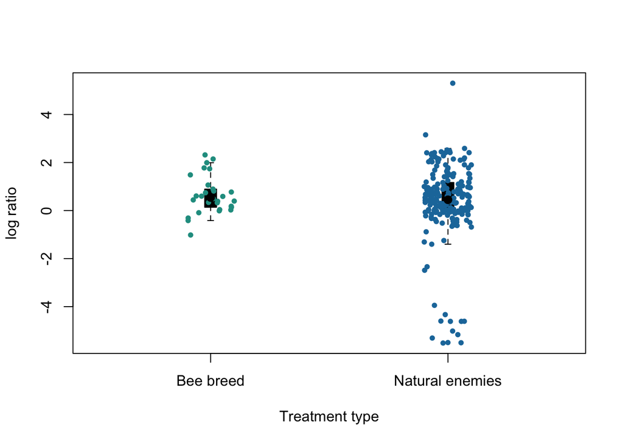

```r
plot(Full_bio$logratio ~ Full_bio$SubCategory1Treatment,
     col ="black",
     bty = "n",
     boxwex = 0.05,
     ylab = "log ratio",
     xlab = "Treatment type",
     pch = 16,
     cex = 0,
     names = c("Bee breed", "Natural enemies"))


#We can plot the points for Bee_breed
points(Full_bio[Full_bio$SubCategory1Treatment == "Bee_breed", "logratio"] ~
         jitter(as.integer(Full_bio[Full_bio$SubCategory1Treatment == "Bee_breed",                                           "SubCategory1Treatment"]),
                  amount = 0.1),
       pch = 16,
       col = rgb(33, 156, 144, max=255),
       cex = 0.8)

points(median(Full_bio[Full_bio$SubCategory1Treatment == "Bee_breed", "logratio"])
       ~ c(1),
       pch = 16,
       col = "black",
       cex = 1.3)


#We can plot the points for Natural_enemies
points(Full_bio[Full_bio$SubCategory1Treatment == "Natural_enemies", "logratio"] ~
         jitter(as.integer(Full_bio[Full_bio$SubCategory1Treatment == "Natural_enemies",                                           "SubCategory1Treatment"]),
                  amount = 0.1),
       pch = 16,
       col = rgb(30, 120, 170, max=255),
       cex = 0.8)


points(median(Full_bio[Full_bio$SubCategory1Treatment == "Natural_enemies",
                       "logratio"]) ~ c(2),
       pch = 16,
       col = "black",
       cex = 1.3)
```